# P10_detection_faux_billets

[figure not shown]

**Contexte et objectifs :**

L’Organisation nationale de lutte contre le faux-monnayage (ONCFM), a pour objectif de mettre en place des méthodes d’identification des contrefaçons des billets en euros. Nous allons mettre en place un algorithme qui soit capable de différencier automatiquement les vrais des faux billets.  
Lorsqu’un billet arrive, nous avons une machine qui consigne l’ensemble de ses caractéristiques géométriques. On observe des différences de dimensions entre les vrais et les faux billets. Ces différences sont difficilement notables à l’œil nu, mais une machine devrait sans problème arriver à les différencier.

Notre mission est de construire un algorithme qui, à partir des caractéristiques géométriques d’un billet, serait capable de définir si ce dernier est un vrai ou un faux billet.

# Sommaire

- Mise en place de l'environnement
  - Importation des librairies
  - Constantes et configuration
  - Fonctions
- Analyse descriptive des données
  - Importation des données
  - Aperçu des données
  - Analyse bivariée
  - Traitement des valeurs manquantes
  - Analyse par composantes principales
- Echantillonnage
- Méthode de régression logistique classique
- Méthode des K-Means
- Méthode des k Nearest Neighbors
- Conclusion
- Programme de détection

# Mise en place de l'environnement

## Importation des librairies

```python
import os, sys
import pandas as pd
import numpy as np

import scipy.stats as st

from scipy.cluster.hierarchy import linkage, fcluster
from sklearn import decomposition
from sklearn import preprocessing
from scipy.cluster.hierarchy import linkage, fcluster, dendrogram, centroid
import scipy.stats as st

import matplotlib.pyplot as plt
import seaborn as sns
from IPython.display import display, set_matplotlib_formats

import warnings
warnings.filterwarnings("ignore")
```

## Constantes et configuration

```python
# path to data folder
DATA_PATH = os.path.realpath('') + '/data/'

# Pandas settings
pd.set_option("display.max_columns", 50)
pd.set_option("display.max_rows", 100)

# seaborn config
sns.set( # Styles Seaborn
    style='whitegrid',
    context="notebook",
    font_scale = 1.2
    )
```

## Fonctions

```python
# import csv file
def import_csv_to_dataframe(filename):
    try:
        return pd.read_csv(DATA_PATH + filename, delimiter=";", encoding='utf8')
    except Exception as e:
        print(">>> Le fichier {} est introuvable.".format(filename))
        sys.exit(e)

def display_circles(pcs, n_comp, pca, axis_ranks, labels=None, label_rotation=0, lims=None):
    for d1, d2 in axis_ranks: # On affiche les 3 premiers plans factoriels, donc les 6 premières composantes
        if d2 < n_comp:

            # initialisation de la figure
            fig, ax = plt.subplots(figsize=(10,10))

            # détermination des limites du graphique
            if lims is not None :
                xmin, xmax, ymin, ymax = lims
            elif pcs.shape[1] < 30 :
                xmin, xmax, ymin, ymax = -1, 1, -1, 1
            else :
                xmin, xmax, ymin, ymax = min(pcs[d1,:]), max(pcs[d1,:]), min(pcs[d2,:]), max(pcs[d2,:])

            # affichage des flèches
            # s'il y a plus de 30 flèches, on n'affiche pas le triangle à leur extrémité
            if pcs.shape[1] < 30 :
                plt.quiver(np.zeros(pcs.shape[1]), np.zeros(pcs.shape[1]),
                   pcs[d1,:], pcs[d2,:],
                   angles='xy', scale_units='xy', scale=1, color="grey")
                # (voir la doc : https://matplotlib.org/api/_as_gen/matplotlib.pyplot.quiver.html)
            else:
                lines = [[[0,0],[x,y]] for x,y in pcs[[d1,d2]].T]
                ax.add_collection(LineCollection(lines, axes=ax, alpha=.1, color='black'))

            # affichage des noms des variables
            if labels is not None:
                for i,(x, y) in enumerate(pcs[[d1,d2]].T):
                    if x >= xmin and x <= xmax and y >= ymin and y <= ymax :
                        plt.text(x, y, labels[i], fontsize='14', ha='center', va='center',
                                 rotation=label_rotation, color="blue", alpha=0.5)

            # affichage du cercle
            circle = plt.Circle((0,0), 1, facecolor='none', edgecolor='b')
            plt.gca().add_artist(circle)

            # définition des limites du graphique
            plt.xlim(xmin, xmax)
            plt.ylim(ymin, ymax)

            # affichage des lignes horizontales et verticales
            plt.plot([-1, 1], [0, 0], color='grey', ls='--')
            plt.plot([0, 0], [-1, 1], color='grey', ls='--')

            # nom des axes, avec le pourcentage d'inertie expliqué
            plt.xlabel('F{} ({}%)'.format(d1+1, round(100*pca.explained_variance_ratio_[d1],1)))
            plt.ylabel('F{} ({}%)'.format(d2+1, round(100*pca.explained_variance_ratio_[d2],1)))

            plt.title("Cercle des corrélations (F{} et F{})".format(d1+1, d2+1))
            plt.show(block=False)

def display_factorial_planes(X_projected, n_comp, pca, axis_ranks, labels=None, alpha=1, illustrative_var=None):
    for d1,d2 in axis_ranks:
        if d2 < n_comp:

            # initialisation de la figure
            fig = plt.figure(figsize=(10,10))

            # affichage des points
            if illustrative_var is None:
                plt.scatter(X_projected[:, d1], X_projected[:, d2], alpha=alpha)
            else:
                illustrative_var = np.array(illustrative_var)
                for value in np.unique(illustrative_var):
                    selected = np.where(illustrative_var == value)
                    plt.scatter(X_projected[selected, d1], X_projected[selected, d2], alpha=alpha, label=value)
                plt.legend()

            # affichage des labels des points
            if labels is not None:
                for i,(x,y) in enumerate(X_projected[:,[d1,d2]]):
                    plt.text(x, y, labels[i],
                              fontsize='14', ha='center',va='center')

            # détermination des limites du graphique
            boundary = np.max(np.abs(X_projected[:, [d1,d2]])) * 1.1
            plt.xlim([-boundary,boundary])
            plt.ylim([-boundary,boundary])

            # affichage des lignes horizontales et verticales
            plt.plot([-100, 100], [0, 0], color='grey', ls='--')
            plt.plot([0, 0], [-100, 100], color='grey', ls='--')

            # nom des axes, avec le pourcentage d'inertie expliqué
            plt.xlabel('F{} ({}%)'.format(d1+1, round(100*pca.explained_variance_ratio_[d1],1)))
            plt.ylabel('F{} ({}%)'.format(d2+1, round(100*pca.explained_variance_ratio_[d2],1)))

            plt.title("Projection des individus (sur F{} et F{})".format(d1+1, d2+1))
            plt.show(block=False)

def display_scree_plot(pca):
    plt.figure(figsize=(10,10))
    scree = pca.explained_variance_ratio_*100
    plt.bar(np.arange(len(scree))+1, scree)
    plt.plot(np.arange(len(scree))+1, scree.cumsum(),c="red",marker='o')
    plt.xlabel("rang de l'axe d'inertie")
    plt.ylabel("pourcentage d'inertie")
    plt.title("Eboulis des valeurs propres")
    plt.show(block=False)

def plot_dendrogram(Z, names):
    plt.figure(figsize=(20,10))
    plt.title('Hierarchical Clustering Dendrogram')
    plt.xlabel('Area')
    plt.axhline(y=12, color='black', linestyle='dashed') # Threshold
    dendrogram(
        Z,
        labels = names,
        #orientation = "left",
    )
    plt.savefig('dendrogramme.png', format='png', bbox_inches='tight')
    plt.show()

    # Compute the silhouette scores for each sample
def silhouette_analysis(X, cluster_labels, n_clusters):

    plt.figure(figsize=(10,10))
    plt.xlim([-0.1, 1])
    plt.ylim([0, len(X) + (n_clusters + 1) * 10])

    sample_silhouette_values = silhouette_samples(X, cluster_labels)

    y_lower = 10
    for i in range(n_clusters):
        # Aggregate the silhouette scores for samples belonging to
        # cluster i, and sort them
        ith_cluster_silhouette_values = sample_silhouette_values[cluster_labels == i]

        ith_cluster_silhouette_values.sort()

        size_cluster_i = ith_cluster_silhouette_values.shape[0]
        y_upper = y_lower + size_cluster_i

        color = cm.nipy_spectral(float(i) / n_clusters)
        plt.fill_betweenx(np.arange(y_lower, y_upper),
                          0, ith_cluster_silhouette_values,
                          facecolor=color, edgecolor=color, alpha=0.7)

        # Label the silhouette plots with their cluster numbers at the middle
        plt.text(-0.05, y_lower + 0.5 * size_cluster_i, str(i))
        #ax1.text(-0.05, y_lower + 0.5 * size_cluster_i, str(i))

        # Compute the new y_lower for next plot
        y_lower = y_upper + 10  # 10 for the 0 samples

    plt.title("Analyse Silhouette des clusters")
    plt.xlabel("Coefficient silhouette")
    plt.ylabel("Cluster label")

    # The vertical line for average silhouette score of all the values
    plt.axvline(x=silhouette_avg, color="red", linestyle="--")

    plt.yticks([])  # Clear the yaxis labels / ticks
    plt.xticks([-0.1, 0, 0.2, 0.4, 0.6, 0.8, 1])
```

Retour au sommaire

# Analyse descriptive des données

L'exploration des données va nous permettre de :

- Proposer des hypothèses sur les relations entre les variables.
- Proposer des pistes de modélisation.

## Importation des données

```python
data = import_csv_to_dataframe("billets.csv")
data.head()
```

|  | is_genuine | diagonal | height_left | height_right | margin_low | margin_up | length |
| --- | --- | --- | --- | --- | --- | --- | --- |
| 0 | True | 171.81 | 104.86 | 104.95 | 4.52 | 2.89 | 112.83 |
| 1 | True | 171.46 | 103.36 | 103.66 | 3.77 | 2.99 | 113.09 |
| 2 | True | 172.69 | 104.48 | 103.50 | 4.40 | 2.94 | 113.16 |
| 3 | True | 171.36 | 103.91 | 103.94 | 3.62 | 3.01 | 113.51 |
| 4 | True | 171.73 | 104.28 | 103.46 | 4.04 | 3.48 | 112.54 |

Dictionnaire des données (six informations géométriques sur un billet) :

- **length** : la longueur du billet (en mm)
- **height_left** : la hauteur du billet (mesurée sur le côté gauche, en mm)
- **height_right** : la hauteur du billet (mesurée sur le côté droit, en mm)
- **margin_up** : la marge entre le bord supérieur du billet et l'image de celui-ci (en mm)
- **margin_low** : la marge entre le bord inférieur du billet et l'image de celui-ci (en mm)
- **diagonal** : la diagonale du billet (en mm).

Nous avons 1 variable qualitative et 6 variables quantitatives.

## Aperçu des données

```python
data.describe(include='all')
```

|  | is_genuine | diagonal | height_left | height_right | margin_low | margin_up | length |
| --- | --- | --- | --- | --- | --- | --- | --- |
| count | 1500 | 1500.000000 | 1500.000000 | 1500.000000 | 1463.000000 | 1500.000000 | 1500.00000 |
| unique | 2 | NaN | NaN | NaN | NaN | NaN | NaN |
| top | True | NaN | NaN | NaN | NaN | NaN | NaN |
| freq | 1000 | NaN | NaN | NaN | NaN | NaN | NaN |
| mean | NaN | 171.958440 | 104.029533 | 103.920307 | 4.485967 | 3.151473 | 112.67850 |
| std | NaN | 0.305195 | 0.299462 | 0.325627 | 0.663813 | 0.231813 | 0.87273 |
| min | NaN | 171.040000 | 103.140000 | 102.820000 | 2.980000 | 2.270000 | 109.49000 |
| 25% | NaN | 171.750000 | 103.820000 | 103.710000 | 4.015000 | 2.990000 | 112.03000 |
| 50% | NaN | 171.960000 | 104.040000 | 103.920000 | 4.310000 | 3.140000 | 112.96000 |
| 75% | NaN | 172.170000 | 104.230000 | 104.150000 | 4.870000 | 3.310000 | 113.34000 |
| max | NaN | 173.010000 | 104.880000 | 104.950000 | 6.900000 | 3.910000 | 114.44000 |

> Il y a les données de 1500 billets avec des valeurs cohérentes.

**Répartition vrai et faux billets :**

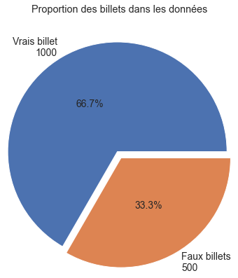

```python
true_count = data[data.is_genuine==True].is_genuine.count()
false_count = data[data.is_genuine==False].is_genuine.count()

labels = ["Vrais billet\n{}".format(true_count)
          ,"Faux billets\n{}".format(false_count)]
values = [true_count / data.shape[0], false_count / data.shape[0]]

# chart
pie, ax = plt.subplots(figsize=[6,6])
colors = ['#99C3FF','#87C0DB']
plt.pie(x=values, autopct="%.1f%%", explode=[0.04]*2, labels=labels, pctdistance=0.5,
        radius=1.2, textprops=dict(size=14))
plt.title("Proportion des billets dans les données", pad=40)
plt.show()
```

> Nous avons les caractéristiques de 1000 vrais billets et 500 faux billets.

**Valeurs manquantes :**

```python
data.info()
```

```
<class 'pandas.core.frame.DataFrame'>
RangeIndex: 1500 entries, 0 to 1499
Data columns (total 7 columns):
 #   Column        Non-Null Count  Dtype
---  ------        --------------  -----
 0   is_genuine    1500 non-null   bool
 1   diagonal      1500 non-null   float64
 2   height_left   1500 non-null   float64
 3   height_right  1500 non-null   float64
 4   margin_low    1463 non-null   float64
 5   margin_up     1500 non-null   float64
 6   length        1500 non-null   float64
dtypes: bool(1), float64(6)
memory usage: 71.9 KB
```

> Les données comportent 37 valeurs manquantes pour la variable **margin_low**.

**Individus ayant des valeurs manquantes :**

```python
filtered_nan_df = data[data['margin_low'].isnull()]
filtered_nan_df['is_genuine'].value_counts()
```

```
True     29
False     8
Name: is_genuine, dtype: int64
```

> Parmis les billets ayant ces valeurs manquantes, on retrouve des vrais et des faux billets. Nous allons réaliser une régression linéaire pour compléter ces valeurs.

## Analyse bivariée

```python
df_main = data.copy()
```

### Pairplot des données

On visualise chacune des variables des billets "deux à deux".

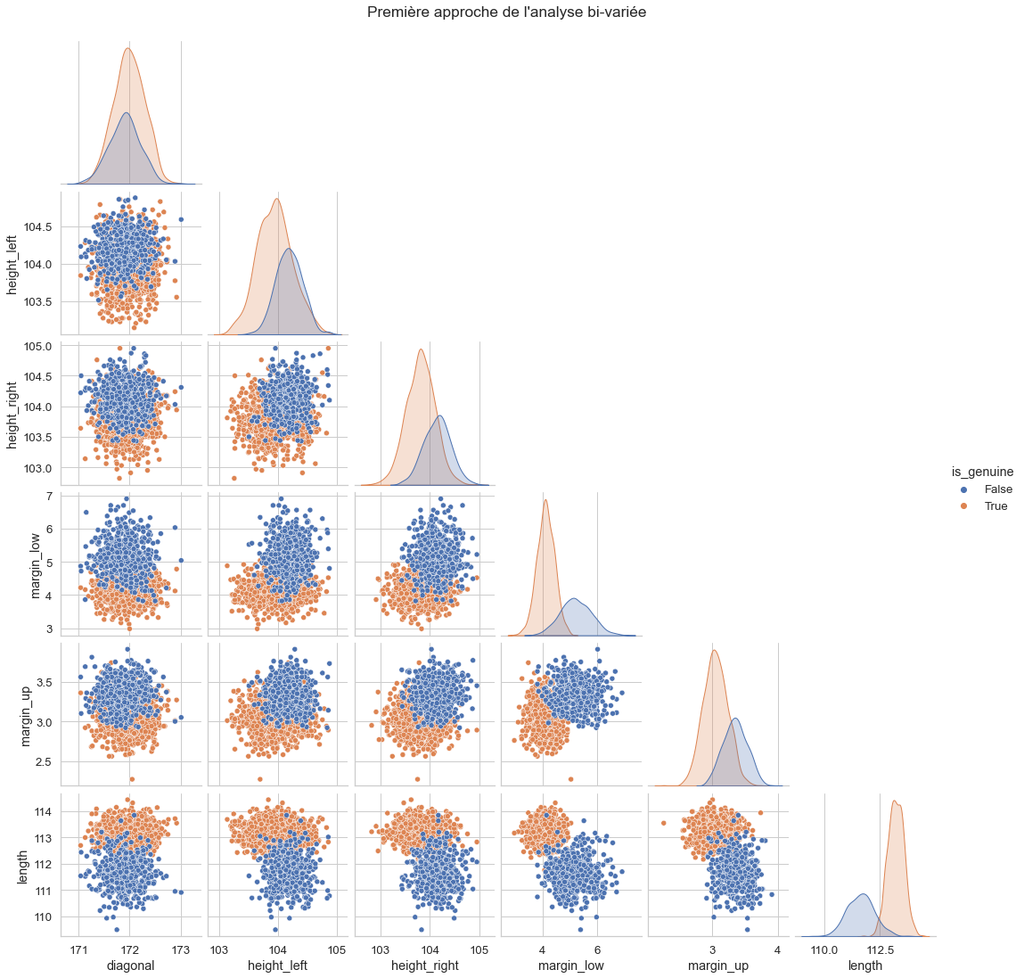

```python
sns.pairplot(df_main, hue = "is_genuine", corner=True)
plt.suptitle("Première approche de l'analyse bi-variée", y=1.02)
plt.show()
```

Les deux variables qui semblent discrimer les billets, semblent être les variables **length** et **margin_low**. On observe de bonnes distrinctions sur les graphiques correspondants.

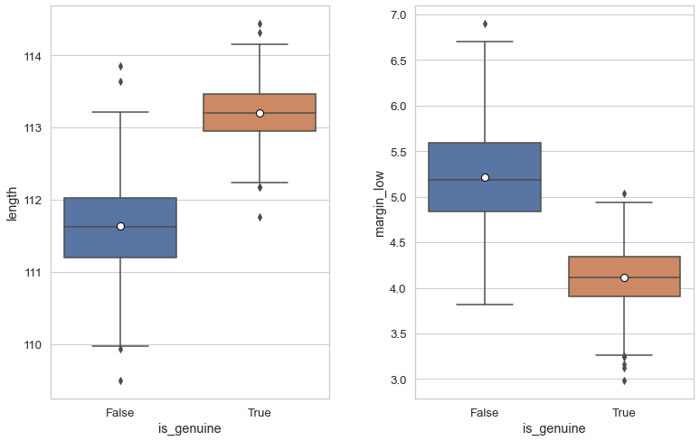

```python
fig, ax = plt.subplots(1,2, figsize=(12,8))
fig.tight_layout(pad=4.0)
meanprops = {"marker":"o","markerfacecolor":"white", "markeredgecolor":"black", "markersize":"8"}
sns.boxplot(data=df_main, y='length', x='is_genuine', showmeans=True, meanprops=meanprops, ax=ax[0])
sns.boxplot(data=df_main, y='margin_low', x='is_genuine', showmeans=True, meanprops=meanprops, ax=ax[1])
plt.show()
```

> Les faux billets sont moins longs que les vrais billets. Leurs marges inférieures sont plus longues.

### Test ANOVA

On réalise des tests ANOVA pour vérifier nos observations.

```python
def get_eta_squared(data, var_a, var_b):
    x = data[var_a]   # variable qualitative
    y = data[var_b]   # variable quantitative

    moyenne_y = y.mean()
    classes = []
    for classe in x.unique():
        yi_classe = y[x==classe]
        classes.append({'ni': len(yi_classe),
                        'moyenne_classe': yi_classe.mean()})
    SCT = sum([(yj-moyenne_y)**2 for yj in y])
    SCE = sum([c['ni']*(c['moyenne_classe']-moyenne_y)**2 for c in classes])
    return SCE/SCT
```

**Variables 'is_genuine', 'length':**

- H0: Les moyennes de **lenght** des vrais billets et faux billets sont confondues.
- H1: Les moyennes ne se confondent pas.

```python
print(f"""eta squared : {get_eta_squared(df_main, 'is_genuine', 'length')}""")

st.f_oneway(df_main[df_main.is_genuine == True].length,
            df_main[df_main.is_genuine == False].length,
           )
```

```
eta squared : 0.721284391221102
```

```
F_onewayResult(statistic=3876.654137826162, pvalue=0.0)
```

**Variables 'is_genuine', 'margin_low':**

- H0: Les moyennes de **margin_low** des vrais billets et faux billets sont les confondues.
- H1: Les moyennes ne se confondent pas.

```python
df_temp = df_main[df_main['margin_low'].notna()]

print(f"""eta squared : {get_eta_squared(df_temp, 'is_genuine', 'margin_low')}""")

st.f_oneway(df_temp[df_temp.is_genuine == True].margin_low,
            df_temp[df_temp.is_genuine == False].margin_low,
           )
```

```
eta squared : 0.6131393378084333
```

```
F_onewayResult(statistic=2315.5535315051015, pvalue=1.3620340580582373e-303)
```

### Matrice de corrélations

On réalise une approche des corrélations entre les variables quantitatives avec la méthode de Pearson.

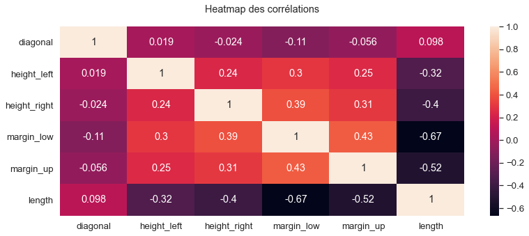

```python
matrix = df_main.drop(columns="is_genuine").corr(method='pearson')

mask = np.triu(np.ones_like(matrix, dtype=np.bool))
plt.figure(figsize=(13, 5))
sns.heatmap(matrix, annot=True)
plt.title("Heatmap des corrélations", pad=20)
plt.show()
```

La matrice des corrélations représentent les dépendances entre variables :

0 : pas ou trés peu de corrélation  
1 : corrélation positive  
1 : corrélation négative

> Les variables **lenght** et **margin_up** semblent être corrélées avec la variable **margin_low** pour laquelle on veut traiter les valeurs manquantes.

## Traitement des valeurs manquantes

La régression linéaire ne fait intervenir qu’une seule variable explicative. Nous allons réaliser des régressions linéaires sur les variables **lenght** et **margin_up** en fonction de **margin_low** et définir la meilleure régression des deux.

**Données sans valeurs manquantes :**

```python
df_temp = df_main[df_main['margin_low'].notna()]
```

### Régression linéaire simple

```python
import statsmodels.formula.api as smf
import statsmodels.stats.api as sms
from statsmodels.compat import lzip
import statsmodels.api as sm
```

- Calcul de la régression **margin_up** et margin_low :

```python
reg_simp = smf.ols('margin_low ~ margin_up', data=df_temp).fit()
print(reg_simp.summary())
```

```
                            OLS Regression Results
==============================================================================
Dep. Variable:             margin_low   R-squared:                       0.186
Model:                            OLS   Adj. R-squared:                  0.186
Method:                 Least Squares   F-statistic:                     334.5
Date:                Mon, 06 Dec 2021   Prob (F-statistic):           1.92e-67
Time:                        18:52:54   Log-Likelihood:                -1325.1
No. Observations:                1463   AIC:                             2654.
Df Residuals:                    1461   BIC:                             2665.
Df Model:                           1
Covariance Type:            nonrobust
==============================================================================
                 coef    std err          t      P>|t|      [0.025      0.975]
------------------------------------------------------------------------------
Intercept      0.5831      0.214      2.725      0.007       0.163       1.003
margin_up      1.2378      0.068     18.288      0.000       1.105       1.371
==============================================================================
Omnibus:                      112.835   Durbin-Watson:                   1.321
Prob(Omnibus):                  0.000   Jarque-Bera (JB):              141.027
Skew:                           0.693   Prob(JB):                     2.38e-31
Kurtosis:                       3.628   Cond. No.                         47.5
==============================================================================

Notes:
[1] Standard Errors assume that the covariance matrix of the errors is correctly specified.
```

Les p-valeurs sont inférieures à 5 %. Le R2 est de 0.186 . Il n'est pas très élevé.

- Calcul de la régression **lenght** et margin_low :

```python
reg_simp = smf.ols('margin_low ~ length', data=df_temp).fit()
print(reg_simp.summary())
```

```
                            OLS Regression Results
==============================================================================
Dep. Variable:             margin_low   R-squared:                       0.445
Model:                            OLS   Adj. R-squared:                  0.444
Method:                 Least Squares   F-statistic:                     1169.
Date:                Mon, 06 Dec 2021   Prob (F-statistic):          8.98e-189
Time:                        18:52:54   Log-Likelihood:                -1045.8
No. Observations:                1463   AIC:                             2096.
Df Residuals:                    1461   BIC:                             2106.
Df Model:                           1
Covariance Type:            nonrobust
==============================================================================
                 coef    std err          t      P>|t|      [0.025      0.975]
------------------------------------------------------------------------------
Intercept     61.5960      1.670     36.881      0.000      58.320      64.872
length        -0.5069      0.015    -34.196      0.000      -0.536      -0.478
==============================================================================
Omnibus:                       95.156   Durbin-Watson:                   1.866
Prob(Omnibus):                  0.000   Jarque-Bera (JB):              133.014
Skew:                           0.552   Prob(JB):                     1.31e-29
Kurtosis:                       3.980   Cond. No.                     1.45e+04
==============================================================================

Notes:
[1] Standard Errors assume that the covariance matrix of the errors is correctly specified.
[2] The condition number is large, 1.45e+04. This might indicate that there are
strong multicollinearity or other numerical problems.
```

Les p-valeurs sont inférieures à 5 %. La variable length est significative.  
Le R2 est de l'ordre de 0.45. Il est moyen et correspond à la dispersion du nuage de points autour de la courbe de régression.

**Choix pour le traitement des données manquantes :**

> Nous choisissons d'étudier la régression avec la variable **lenght** qui a un meilleur coefficient de détermination (R2 = 0,445). Ce coefficient est un indicateur de la qualité du modèle.

**Visualisation de la droite de régression :**

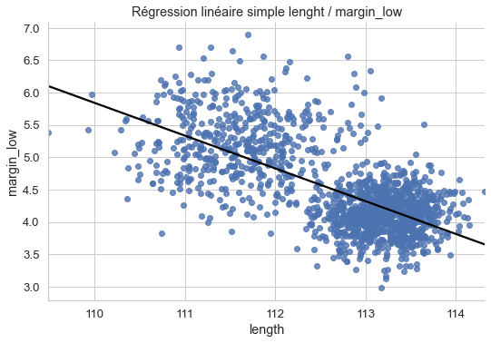

```python
plt.figure(figsize=(8,8))
ax = sns.lmplot(x="length", y="margin_low", data=df_temp,
                ci=None, line_kws={'color':'black'}, aspect=1.5)
ax.set(xlabel='length', ylabel='margin_low')
plt.title("Régression linéaire simple lenght / margin_low")
plt.show()
```

### Homoscédasticité et normalité des résidus

Le modèle linéaire fonctionne avec des hypothèses :

- Distribution gaussienne des résidus
- Homoscedasticité des résidus (s'observe lorsque la dispersion des résidus est homogène)

Nous allons ici vérifier ces hypothèses pour déterminer la robustesse du modèle.

**Représentation des valeurs ajustées en fonction des valeurs observées :**

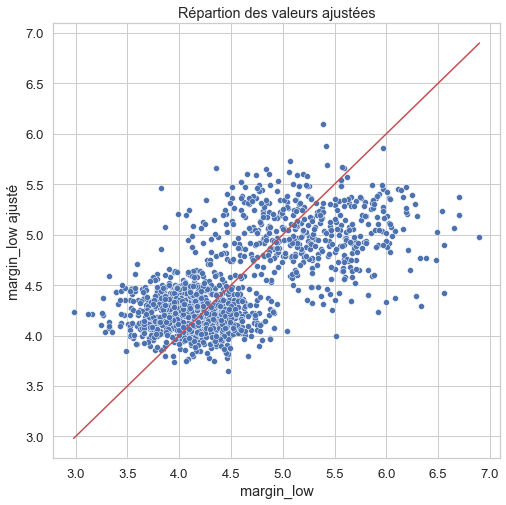

```python
df_temp['margin_low_ajust_s'] = reg_simp.predict()

X_plot = [df_temp['margin_low'].min(), df_temp['margin_low'].max()]

plt.figure(figsize=(8,8))
ax = sns.scatterplot(x="margin_low", y="margin_low_ajust_s", data=df_temp)
ax.set(xlabel='margin_low', ylabel='margin_low ajusté')
plt.plot(X_plot, X_plot, color='r')
plt.title("Répartion des valeurs ajustées")
plt.show()
```

La droite qui s'affiche est la première bissectrice. Le modèle n'est pas parfait, les valeurs réelles et les valeurs ajustées ne sont pas égales.  
Les résidus semblemnt avoir une dispersion à peu prés constante.

**Réprésentation des résidus :**

```python
df_main['residu_s'] = reg_simp.resid
```

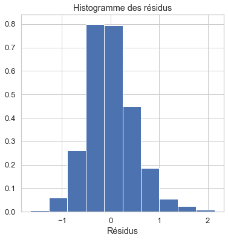

```python
plt.figure(figsize=(6,6))
plt.hist(df_main['residu_s'], density=True)
plt.xlabel('Résidus')
plt.title('Histogramme des résidus')
plt.show()
```

L’allure de l’histogramme est assez classique : centrée et à peu près symétrique.

**Normalité des résidus :**

le diagramme Quantile-Quantile est un outil graphique permettant d'évaluer la pertinence de l'ajustement d'une distribution donnée à un modèle théorique. On trace ici ce diagramme pour visualisé la normalité des résidus.

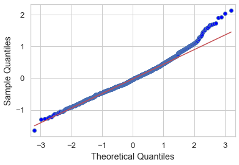

```python
plt.figure(figsize=(8,8))
fig = sm.qqplot(reg_simp.resid, line='q')
plt.show()
```

On observe que les points suivent globalement la droite qui passe par les quartiles. Les résidus semblent donc suivre la loi de normalité.  
Vérifions avec les tests statistiques :

```python
name = ["Jarque-Bera", "Chi^2 two-tail prob.", "Skew", "Kurtosis"]
test = sms.jarque_bera(reg_simp.resid)
lzip(name, test)
```

```
[('Jarque-Bera', 133.01408667862088),
 ('Chi^2 two-tail prob.', 1.307248252771056e-29),
 ('Skew', 0.5524960920847783),
 ('Kurtosis', 3.9803272625742934)]
```

**Homoscédasticité :**

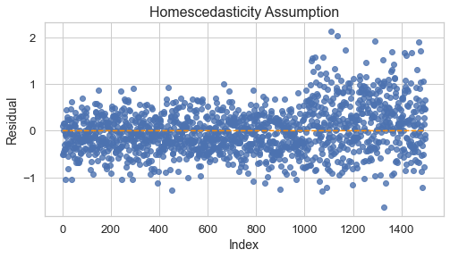

```python
# Plotting the residuals
plt.subplots(figsize=(8, 4))
plt.scatter(x=df_main.index, y=df_main.residu_s, alpha=0.8)
plt.plot(np.repeat(0, len(df_main.index)+2), color='darkorange', linestyle='--')

plt.ylabel('Residual', fontsize=14)
plt.xlabel('Index', fontsize=14)
plt.title('Homescedasticity Assumption', fontsize=16)
plt.show()
```

```python
name = ["Lagrange multiplier statistic", "p-value", "f-value", "f p-value"]
test = sms.het_breuschpagan(reg_simp.resid, reg_simp.model.exog)
lzip(name, test)
```

```
[('Lagrange multiplier statistic', 60.9027372588655),
 ('p-value', 5.996540571030989e-15),
 ('f-value', 63.46128867069214),
 ('f p-value', 3.2637138477321717e-15)]
```

### Prévision des valeurs manquantes

Pour rappel : la variable margin_low contient 37 valaurs manquantes.

```python
filtered_nan_df.head()
```

|  | is_genuine | diagonal | height_left | height_right | margin_low | margin_up | length |
| --- | --- | --- | --- | --- | --- | --- | --- |
| 72 | True | 171.94 | 103.89 | 103.45 | NaN | 3.25 | 112.79 |
| 99 | True | 171.93 | 104.07 | 104.18 | NaN | 3.14 | 113.08 |
| 151 | True | 172.07 | 103.80 | 104.38 | NaN | 3.02 | 112.93 |
| 197 | True | 171.45 | 103.66 | 103.80 | NaN | 3.62 | 113.27 |
| 241 | True | 171.83 | 104.14 | 104.06 | NaN | 3.02 | 112.36 |

**Prédiction :**

On prédit grâce à la régression linéaire les valeurs manquantes.

```python
pred = reg_simp.predict(filtered_nan_df)
pred.head()
```

```
72     4.427556
99     4.280567
151    4.356596
197    4.184264
241    4.645504
dtype: float64
```

**Remplacement des valaurs manquantes :**

```python
for index, value in pred.items():
    df_main.at[index, 'margin_low'] = value
df_main.drop('residu_s', inplace=True, axis=1)
```

```python
df_main.info()
```

```
<class 'pandas.core.frame.DataFrame'>
RangeIndex: 1500 entries, 0 to 1499
Data columns (total 7 columns):
 #   Column        Non-Null Count  Dtype
---  ------        --------------  -----
 0   is_genuine    1500 non-null   bool
 1   diagonal      1500 non-null   float64
 2   height_left   1500 non-null   float64
 3   height_right  1500 non-null   float64
 4   margin_low    1500 non-null   float64
 5   margin_up     1500 non-null   float64
 6   length        1500 non-null   float64
dtypes: bool(1), float64(6)
memory usage: 71.9 KB
```

> Nous n'avons plus de valeurs manquantes dans les données. Celles-ci ont été complétés grâce à la prévision par régression linéaire.

Retour au sommaire

## ACP

On réalise une analyse en composantes principales pour réduire les 6 variables et représenter nos billets dans un espace à 2 dismensions. On pourra ainsi observer les clusters et avoir 2 variables synthétiques.

**Centrage et réduction :**

Les variables ne sont pas exprimées dans les mêmes unités. On réalise donc un centrage et une réduction.

```python
df_temp = df_main.drop(['is_genuine'], axis=1)
X = df_temp.values
names = df_temp.index

std_scale = preprocessing.StandardScaler().fit(X)
X_scaled = std_scale.transform(X)
df_norm = pd.DataFrame(X_scaled, columns=df_temp.columns)
```

```python
df_norm.head()
```

|  | diagonal | height_left | height_right | margin_low | margin_up | length |
| --- | --- | --- | --- | --- | --- | --- |
| 0 | -0.486540 | 2.774123 | 3.163240 | 0.054533 | -1.128325 | 0.173651 |
| 1 | -1.633729 | -2.236535 | -0.799668 | -1.083798 | -0.696799 | 0.471666 |
| 2 | 2.397823 | 1.504756 | -1.291191 | -0.127600 | -0.912562 | 0.551901 |
| 3 | -1.961498 | -0.399294 | 0.060498 | -1.311464 | -0.610494 | 0.953075 |
| 4 | -0.748754 | 0.836669 | -1.414072 | -0.673998 | 1.417677 | -0.158750 |

> Les données sont bien normalisées, on peut donc faire une analyse par composantes principales.

**Analyse sur 2 composantes :**

```python
# choix du nombre de composantes à calculer
n_comp = 4

# Calcul des composantes principales
pca = decomposition.PCA(n_components=n_comp)
pca.fit(X_scaled)
```

```
PCA(n_components=4)
```

```python
def display_scree_plot(pca):
    plt.figure(figsize=(10,10))
    scree = pca.explained_variance_ratio_*100
    plt.bar(np.arange(len(scree))+1, scree)
    plt.plot(np.arange(len(scree))+1, scree.cumsum(),c="red",marker='o')
    plt.xlabel("rang de l'axe d'inertie")
    plt.ylabel("pourcentage d'inertie")
    plt.title("Eboulis des valeurs propres")
    plt.show(block=False)
```

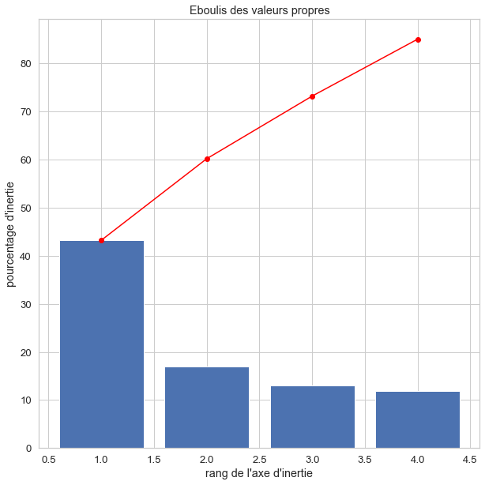

```python
display_scree_plot(pca)
```

> Etant donnée que nous avons 6 variables, le seuil a prendre en considération est de 16.7% (100/6). Nous analyserons donc seulement les variables F1 et F2 qui réprésentent 60,2% de l'inertie totale.  
> Les 4 autres variables représentent chacune moins de 15% de l'inertie totale, soit moins que notre seuil.

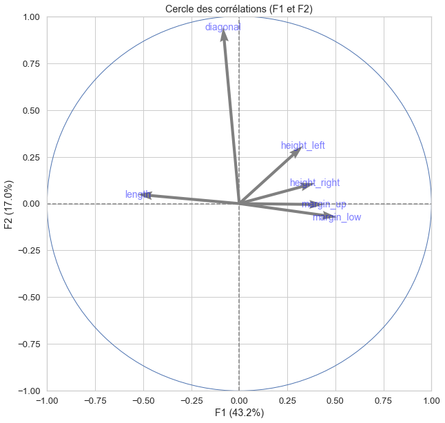

```python
pcs = pca.components_
display_circles(pcs, n_comp, pca, [(0,1)], labels = np.array(df_norm.columns))
```

La **composante F1** représente 43% de l'inertie totale. Les variables qui seraient corrélées sont la hauteur et les marges :

- height_left
- height_right
- margin_up
- margin_low

La **composante F2** représente 17% de l'inertie totale. Elle est corrélée à la longueur de la diagonale.

**Projection des individus sur le premier plan factoriel :**

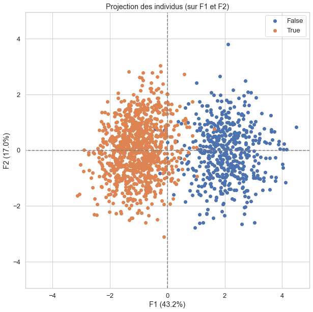

```python
df_norm["is_genuine"] = data["is_genuine"]
X_projected = pca.transform(X_scaled)
display_factorial_planes(X_projected, n_comp, pca, [(0,1)], illustrative_var = df_norm["is_genuine"])
plt.show()
```

On observe deux nuages de points qui se distinguent sur la composante F1. Les vrais billets se situent sur une partie gauche de la projection. L'authenticité des billets semble être corrélée par la composantes F1.

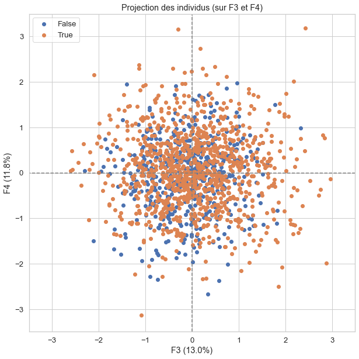

```python
display_factorial_planes(X_projected, n_comp, pca, [(2,3)], illustrative_var = df_norm["is_genuine"])
plt.show()
```

Comme vu plus haut, la disctinction de l'authenticité des billets par rapport aux composantes F3 et F4 ne semble par être possible. Les nuages de points se confondent.  
On interprétre donc seulement la projection des individus dans le premier plan factoriel.

**Conclusion :**

> On distingue bien deux clusters sur la projection, l'un pour les billets valides et l'autre pour les faux billets. Ils sont caractérisés particulierrement par la composantes F1 et peu par F2.

Les billets valides auraient par rapport aux faux billets :

- une plus petite hauteur
- une image moins centrée
- un longueur plus grande

La diagonale ne permettrait pas de distinguer les 2 types de billets.

Retour au sommaire

# Echantillonnage

**Création des datasets :**

On cherche ici à échantilloner nos données pour que l'apprentissage soit moins lourd. Cet échantillon est représentatif de toutes les données.

- **Le training set :** Il va nous permettre d’entraîner nos modèles et sera utilisé par l’algorithme d’apprentissage.
- **Le testing set :** Il permet de mesurer l’erreur du modèle final sur des données tests. On va mesurer la performance des modèles sur ces données.

Les modèles seront complètement optimisés pour les données à l'aide desquelles ils ont été créés. L'erreur sera minimal sur ces données. Elle sera toujours plus élevée sur des données que le modèle n'aura jamais vues. Pour minimiser ce problème, la meilleure approche est de séparer dès le départ notre jeu de données en deux parties distinctes.

> On décide d'échantillonner comme suit :
> - 80 % pour le training set
> - 20 % pour le testing set.

```python
from sklearn.model_selection import train_test_split

feature_cols = ['diagonal', 'height_left', 'height_right', 'margin_low', 'margin_up', 'length']
X = df_norm[feature_cols]
y = df_norm['is_genuine']

X_train, X_test, y_train, y_test = train_test_split(X, y, train_size=0.8, random_state=0)
```

```python
display(X_train.shape, X_test.shape, y_train.shape, y_test.shape)
```

```
(1200, 6)
```

```
(300, 6)
```

```
(1200,)
```

```
(300,)
```

Retour au sommaire

# Méthode de régression logistique classique

Nous somms en modalité binaire car la variable cible **is_genuine** n'a que 2 modalités. On peut utiliser l'algorithme de Newton. Le nombre d'itération est de 100 par defaut.

## Implémentation du modèle

```python
from sklearn.linear_model import LogisticRegression
```

```python
reg_modele_logit = LogisticRegression(penalty='none',solver='newton-cg')

#apprentissage
reg_log_modele = reg_modele_logit.fit(X_train, y_train)
```

## Evaluation du modèle

**Coefficients :**

```python
print(pd.DataFrame({"var":X_train.columns,"coef":reg_log_modele.coef_[0]}))
```

```
            var      coef
0      diagonal  0.133414
1   height_left -0.537953
2  height_right -0.985407
3    margin_low -3.509150
4     margin_up -2.485888
5        length  4.777580
```

**Constante :**

```python
print(reg_log_modele.intercept_)
```

```
[2.21842943]
```

**Calcul log-vraisemblance :**

```python
proba01 = reg_log_modele.predict_proba(X_train)
proba1 = proba01[:,1]

log_likelihood = np.sum(y_train * np.log(proba1) + (1.0-y_train)*np.log(1.0-proba1))
print(log_likelihood)
```

```
-36.52864222173345
```

## Prédictions

```python
y_pred_logic = reg_modele_logit.predict(X_test)
```

```python
proba = reg_log_modele.predict_proba(X_test)
scores = proba[:,1]
print(proba[0:10])
```

```
[[3.55668211e-03 9.96443318e-01]
 [4.99857357e-04 9.99500143e-01]
 [9.87403213e-01 1.25967865e-02]
 [1.93547915e-01 8.06452085e-01]
 [9.99999864e-01 1.36480084e-07]
 [9.99963840e-01 3.61603413e-05]
 [4.05687644e-02 9.59431236e-01]
 [1.62098412e-04 9.99837902e-01]
 [1.63751414e-06 9.99998362e-01]
 [9.99573089e-01 4.26910730e-04]]
```

**Courbe ROC :**

```python
from sklearn import metrics

fpr, tpr, _ = metrics.roc_curve(y_test, scores)
```

```python
auc = metrics.auc(fpr, tpr)
print(auc)
```

```
0.999847646132751
```

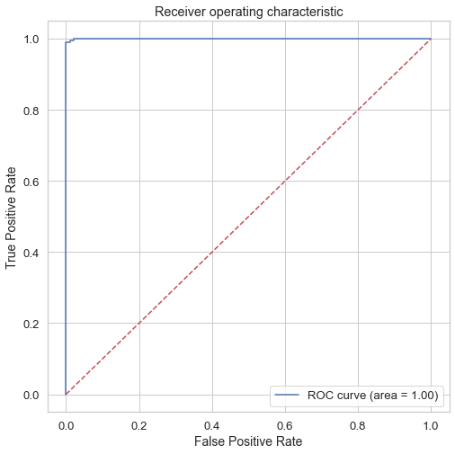

```python
fig, ax = plt.subplots(figsize=(8, 8))
plt.plot(fpr,tpr,label="ROC curve (area = %0.2f)" % auc)
plt.plot([0,1],[0,1],"r--")
plt.legend(loc=4)
plt.title('Receiver operating characteristic')
ax.set_ylabel('True Positive Rate', fontsize=14)
ax.set_xlabel('False Positive Rate', fontsize=14)
plt.show()
```

> On observe alors un AUC (area under curve) proche de 1.

**Score sur les training set et testing set :**

```python
print("Training score:", round(reg_log_modele.score(X_train, y_train), 5))
print("Testing score:", round(reg_log_modele.score(X_test, y_test), 5))
```

```
Training score: 0.99083
Testing score: 0.99333
```

> Le modèle donne de bons scores proche de 1 sur les deux jeux de données. On peut en déduire que le modèle est bien calibré.

**Matrice de confusion :**

La matrice de confusion permet de comparer les résultats en fonction de nos billets de références.

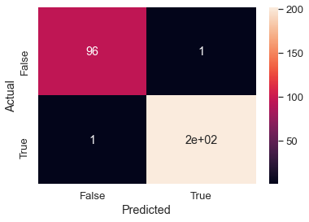

```python
cnf_matrix = pd.crosstab(y_test, y_pred_logic, rownames=['Actual'], colnames=['Predicted'])
sns.heatmap(cnf_matrix, annot=True)
```

> Vrais positifs : 202  
> Vrais negatifs : 96  
> Faux positifs : 1  
> Faux negatifs : 1

```python
print(metrics.classification_report(y_test, y_pred_logic))
```

```
              precision    recall  f1-score   support

       False       0.99      0.99      0.99        97
        True       1.00      1.00      1.00       203

    accuracy                           0.99       300
   macro avg       0.99      0.99      0.99       300
weighted avg       0.99      0.99      0.99       300
```

> La méthode de régression logistique affiche un bon score de précision et peu de faux positifs. Elle présente un AUC proche de 1.

Retour au sommaire

# Méthode des K Means

La méthode des K-Means permet tout d'abord déterminer 2 clusters parmis les individus correspondant aux vrais et faux billets. On détermine ensuite pour chacun des billets du jeu de donnée test, le groupe auquel il appartient.

## Implémentation et prédiction

On fixe le nombre de clusters à 2 puisque l'on a 2 modalités pour la variable **is_genuine**.

```python
from sklearn import cluster

# Nombre de clusters souhaités
n_clust = 2

# Clustering par K-means
modele_kmeans = cluster.KMeans(n_clusters=n_clust)
class_modele_kmeans = modele_kmeans.fit(X_train)

# Récupération des clusters attribués à chaque individu
k_means_clusters = class_modele_kmeans.labels_

df_K_means = pd.DataFrame(k_means_clusters)

y_pred_kmean = modele_kmeans.predict(X_test)
```

## Centroïdes

**Calcul des centroids :**

```python
# choix du nombre de composantes à calculer
n_comp = 2

# Calcul des composantes principales
pca2 = decomposition.PCA(n_components=n_comp)
pca2.fit(X_train)
X_scaled_projected_2 = pca2.transform(X_train)
```

```python
centroids = class_modele_kmeans.cluster_centers_
centroids_projected = pca2.transform(centroids)
```

**Visualisations des centroïdes sur le 1er plan factoriel de l'ACP :**

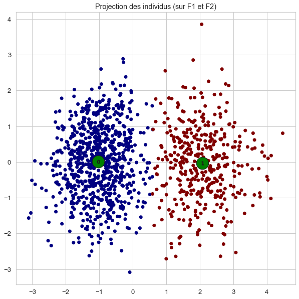

```python
plt.figure(figsize=(10,10))
plt.scatter(X_scaled_projected_2[:, 0], X_scaled_projected_2[:, 1], c=k_means_clusters, cmap = 'jet')

plt.scatter(centroids_projected[:, 0], centroids_projected[:, 1], marker='o',
                c="green", alpha=1, s=600, edgecolor='k')
for i, c in enumerate(centroids_projected):
        plt.scatter(c[0], c[1], marker='$%d$' % i, alpha=1,
                    s=50, edgecolor='k')

plt.title("Projection des individus (sur F1 et F2)")
plt.show(block=False)
```

Avec l'algorithme des K-means, nous observons deux clusters, l'un pour les vrais billets et l'autre pour les faux billets.

## Evaluation du modèle

La matrice de confusion nous permet de vérifier que l'algorithme déterminer bien l'authenticité des billets.

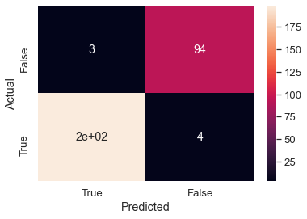

```python
# Détermination des clusters True et False
valeurs_uniques, compte_des_valeurs_uniques = np.unique(y_pred_kmean, return_counts=True)

# On renomme les clusters
cluster_true = [
    index for index in valeurs_uniques if compte_des_valeurs_uniques[index] == max(compte_des_valeurs_uniques)]
cluster_false = [
    index for index in valeurs_uniques if compte_des_valeurs_uniques[index] != max(compte_des_valeurs_uniques)]

dict = {True: cluster_true, False: cluster_false}
y_test.replace(dict)

cnf_matrix = pd.crosstab(y_test, y_pred_kmean, rownames=['Actual'], colnames=['Predicted'])

cnf_matrix=cnf_matrix.rename(columns = {cluster_true[0]:'True'})
cnf_matrix=cnf_matrix.rename(columns = {cluster_false[0]:'False'})

sns.heatmap(cnf_matrix, annot=True)
```

```python
y_pred_kmean_list = []

for x in y_pred_kmean:
    if x == cluster_true[0] :
        y_pred_kmean_list.append(True)
    else:
        y_pred_kmean_list.append(False)

print(metrics.classification_report(y_test, y_pred_kmean_list))
```

```
              precision    recall  f1-score   support

       False       0.96      0.97      0.96        97
        True       0.99      0.98      0.98       203

    accuracy                           0.98       300
   macro avg       0.97      0.97      0.97       300
weighted avg       0.98      0.98      0.98       300
```

Les deux clusters sont bien corrélés aux authenticité des billets. On note toutefois des billets faux positifs et faux négatifs.

Retour au sommaire

# Méthode des k Nearest Neighbors

L'algorithme (plus proches voisins) consiste à choisir les k données les plus proches du point étudié afin d’en prédire sa valeur. Il se base uniquement sur les données d’entraînement. Toutes les données d'entraînement sont concervées en mémoire (memory-based) et il convient donc aux problèmes d'assez petite taille.

## Implémentation et prédiction

```python
from sklearn import neighbors

knn = neighbors.KNeighborsClassifier(n_neighbors=2)
knn.fit(X_train, y_train)

y_pred_knn = knn.predict(X_test)
```

## Evaluation du modèle

**Score de précision :**

```python
print("Training score:", round(knn.score(X_train, y_train), 5))
print("Testing score:", round(knn.score(X_test, y_test), 5))
```

```
Training score: 0.99333
Testing score: 0.97
```

> Le modèle a un bon score de précision.

**Matrice de confusion :**

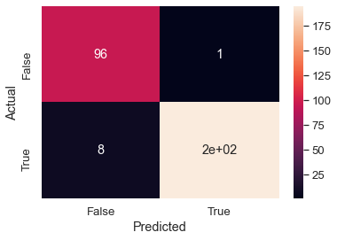

```python
cnf_matrix = pd.crosstab(y_test, y_pred_knn, rownames=['Actual'], colnames=['Predicted'])
sns.heatmap(cnf_matrix, annot=True)
```

```python
print(metrics.classification_report(y_test, y_pred_knn))
```

```
              precision    recall  f1-score   support

       False       0.92      0.99      0.96        97
        True       0.99      0.96      0.98       203

    accuracy                           0.97       300
   macro avg       0.96      0.98      0.97       300
weighted avg       0.97      0.97      0.97       300
```

> C'est la méthode qui affiche le plus petit score des méthodes que l'on a essayé plus haut. La prédiction reste cependant bonne avec un taux de réussite de 97%.

# Conclusion

```python
print(f"""
Score régression logistique classique : {round(metrics.f1_score(y_test, y_pred_logic), 3)}
Score méthode des k-means             : {round(metrics.f1_score(y_test, y_pred_kmean_list), 3)}
Score méthode des k Nearesr Neighbors : {round(metrics.f1_score(y_test, y_pred_knn), 3)}
""")
```

```
Score régression logistique classique : 0.995
Score méthode des k-means             : 0.983
Score méthode des k Nearesr Neighbors : 0.977
```

> Nous devions mettre en place un algorithme qui soit capable de différencier automatiquement les vrais des faux billets. Pour nos prédictions, nous avons essayé plusieurs méthodes d'apprentissage parmis lesquells des méthode de régression et de classification. On a pu comparer le taux de précisions de ces dernières.

> Pour notre programme de détection, on décide de choisir la méthode de régression logistique qui offre un score plus élevé.

Retour au sommaire

# Programme de détection

Le programme de détection est basé sur un apprentissage surpervisé par régression logistique. Il permet de prédictire l'authenticité des billets avec chacun une probabilité de risque.

```python
DATA_TEST_PATH = os.path.realpath('') + '/to_test/'

files_in_directory = os.listdir(DATA_TEST_PATH)
files_in_directory = list(filter(lambda f: f.endswith('.csv'), files_in_directory))

for filename in files_in_directory:
    print(f"""
    -----------------------------------------
    Analyse du fichier : {filename}
    """)

    # imporation des données
    df_to_test = pd.read_csv(DATA_TEST_PATH + filename, delimiter=",", encoding='utf8')

    df_prep = df_to_test.copy()
    df_prep.drop('id', inplace=True, axis=1)

    # centrage et réduction
    X = df_prep.values
    names = df_prep.index

    std_scale = preprocessing.StandardScaler().fit(X)
    X_scaled = std_scale.transform(X)

    df_prep = pd.DataFrame(X_scaled, columns=df_prep.columns)

    # prédiction
    y_pred_logic = reg_log_modele.predict(df_prep)

    df_to_test['prediction'] = y_pred_logic

    # probabilité
    proba_false = reg_log_modele.predict_proba(df_prep)[:, 0]
    proba_false = [round(num, 5) for num in proba_false]
    df_to_test['probability_is_false'] = proba_false

    # visualisation
    df_result = df_to_test[["id", "prediction", "probability_is_false"]].set_index("id")
    print(df_result)
```

```
    -----------------------------------------
    Analyse du fichier : billets_production.csv

     prediction  probability_is_false
id
A_1       False               0.98906
A_2       False               0.99809
A_3       False               0.99925
A_4        True               0.00000
A_5        True               0.00000
```

Retour au sommaire